# Model formulas

In this note we will examine the use of model formulas to specify linear models. The model formula syntax provides a powerful way to specify a wide range of statistical models and functions.

For categorical variables, specifying main effects and interactions is important for modeling. We will examine how they work, and how to interpret the output.

- Main effects
- Interaction effects
- Model formula syntax
- Specifying contrasts

## Flowering time dataset

We will use data from [Burghardt et. al. 2015](https://nph.onlinelibrary.wiley.com/doi/epdf/10.1111/nph.13799) who studied the effect of temperature fluctuations on flowering time in *Arabidopsis thaliana*. We will use a small subset of the data for the purposes of this note. They performed [three experiments](https://datadryad.org/resource/doi:10.5061/dryad.65d76) – we will use data from the first experiment where a number of flowering time mutants were studied. We will look at data from just six of the mutants studied: “Col-Ama”, “Col-FRI”, “vin3-4”, “vin3-4 FRI”, “hua2-3”, and “hua2-3 FRI”, all of which were subjected to vernalization (28-day cold treatment). Mutants with “FRI” in the label also have the FRIGIDA locus introgresses; this locus induces late flowering. We will use days to flower as our response variable. We will divide the data into three subsets, depending on the mutation present (“Col”, “vin3-4” or “hua2-3”).

Each subset of the data will be in the format of a classic 2x2 factorial experiment where there are two factors (genotype and vernalization), each with two levels. The vernalization treatments are “vernalization” (`V`) or “no vernalization” (`NV`). There are two genotype levels, one with FRI (FRIGIDA mutation) and the other without FRI.

First we will read in the data and subset it to get three small datasets separated by the mutation.

```r
## set figure options)
options(repr.plot.width = 7, repr.plot.height = 7)
## load library
library(tidyverse)
vernURL <- "https://dryad-assetstore-merritt-west.s3.us-west-2.amazonaws.com/ark%3A/13030/m5bs3rq2%7C1%7Cproducer/Experiment1.txt?response-content-type=text%2Fplain&X-Amz-Security-Token=IQoJb3JpZ2luX2VjECMaCXVzLXdlc3QtMiJHMEUCIQD6Y1tjlnbdxXoxB981X0iQYSs82ilNlkNqS7iToZ8vkQIgUqqlS8o7Iseqw%2F9AWWt9uWs4fbg4PT7Lvpd1x%2FrjeVgq%2BgMIPBAAGgw0NTE4MjY5MTQxNTciDL1miuRKZfLt%2FzpNsirXA%2B6hRGKnBWqGX0GQ6yNWAk1NF5JSZw0pgPf%2BMfXCyV0kQVChduMk3HdNEdfFEmMbe44nFCwjBK1EBT6LngceXAUiA3n%2BpEJMiiWS5xUcpeTJ22m8X8y8czMtBbPZnr53dJdo69kuSaicB1qKqaRTrkw0VtYi7o2Fpb6EcLF7w28vbtWPTslxSNzDOMAfEnhCcVmk0BDhKNtQ5gDf%2Bl%2Bo%2FYzOXMn9aLA%2FkoKA6iOwvw%2FlK2h5ra0sAmQWRyON%2BRKUfcsJvITVEMFOt5A8rjX0MYYwnH26xCVS1PFArDB%2B3FxMINTuK5yjIOvK3FDJjMRBwehPwwMu5OGKKMu3MsejUmTzjl8a1QYsT9wphho1juPwTNp6zvQNdcuNOhnW4pi%2BgBtsAiZ3OnDqM2SKDxgLXw0lW7CuRGJWpaJpzcW%2FyOUzp8lUrn7i8AbNoGGZr4ToWvBEIsRAnZwm%2B5ROJIUlQfynJxVk%2FD1aUgmRQxV45RlD6%2FM%2FGSLckiW5rM8RPg84WSAFtcftkPKxdV57iG3E95OiU3WhQV1Us2ma9sq8y1jumvf3eZMdMNdYjIstRpvsyoozfhISaVH%2Bo7r%2Bhi1Y%2FfkHphESvZzkvy49hzdngpHV0JQ%2BbkhkZDDMgfmOBjqlARkMt9FttAc3NALXrg01RgyeVh3ykzSv65fd6S1%2FoTQVNE3y0SGW6mfQOM4SvDKoE%2F%2Fyv54us9pQ%2FKip8o8nMZugmChPgoOFxbGlcpL%2F0SQb50snG%2FscHwdWkWQNg58%2Boqa1bIkGYo6PqcTCfYM%2FELgm5Mijj6V5ZK%2FSE79nx3R7oyrs%2FC2%2FsAEw%2BB%2FNRaQzXQOvxWnQMciUbqsUSzh0ZXtUt5XZYA%3D%3D&X-Amz-Algorithm=AWS4-HMAC-SHA256&X-Amz-Date=20220112T033910Z&X-Amz-SignedHeaders=host&X-Amz-Expires=14400&X-Amz-Credential=ASIAWSMX3SNW56ARTNT5%2F20220112%2Fus-west-2%2Fs3%2Faws4_request&X-Amz-Signature=6bac424cce3b930399e9577f9856048cac80e781584060aeb87bbcf34cc58000"
tmpfile <- tempfile(fileext="txt")
download.file(vernURL,tmpfile)
vern <- read.table(tmpfile,fill = TRUE,header=T)
library(DT)
datatable(head(vern))
```

|  | Genotype | Background | Background.simple | Treatment | Treatment.V | Chamber.ID | Chamber.Irradiance | Vernalization | Daylength | Temperature | Fluctuation | Survival.Bolt | Bolt | Days.to.Bolt | Days.to.Flower | Rosette.leaf.num | Cauline.leaf.num | Blade.length.mm | Total.leaf.length.mm | Blade.ratio | Notes |
| --- | --- | --- | --- | --- | --- | --- | --- | --- | --- | --- | --- | --- | --- | --- | --- | --- | --- | --- | --- | --- | --- |
| 1 | agl24-1 | Col | Col | 12ConLD | 12ConLDNV | 7B | Low | NV | 16 | 12 | Con | Y | Y | 35 | 48 | 18 | 7 | 15.6 | 29.7 | 0.525252525 |  |
| 2 | agl24-1 | Col | Col | 12ConLD | 12ConLDNV | 7B | Low | NV | 16 | 12 | Con | Y | Y | 35 | 48 | 17 | 5 | 16.4 | 32.9 | 0.498480243 |  |
| 3 | agl24-1 | Col | Col | 12ConLD | 12ConLDNV | 4T | High | NV | 16 | 12 | Con | Y | Y | 36 | 48 | 22 | 6 | 10.6 | 20.4 | 0.519607843 |  |
| 4 | agl24-1 | Col | Col | 12ConLD | 12ConLDNV | 4T | High | NV | 16 | 12 | Con | Y | Y | 36 | 47 | 18 | 5 | 15.9 | 25.6 | 0.62109375 |  |
| 5 | agl24-1 | Col | Col | 12ConLD | 12ConLDNV | 4T | High | NV | 16 | 12 | Con | Y | Y | 38 | 50 | 24 | 8 | 14.4 | 26.4 | 0.545454545 |  |
| 6 | agl24-1 | Col | Col | 12ConLD | 12ConLDNV | 7B | Low | NV | 16 | 12 | Con | Y | Y | 39 | 53 | 20 | 7 | 15.9 | 29.7 | 0.535353535 |  |

Now we make three datasets depending on the mutation present. We also select the three columns of interest to us.

```r
## select three columns of interest
vern <- select(vern,Genotype,Vernalization,Days.to.Flower)
## filter to only two genotypes of interest for three sets of genotypes
vern3 <- filter(vern,(Genotype=="Col Ama")|(Genotype=="Col FRI"))
vern2 <- filter(vern,(Genotype=="vin3-4")|(Genotype=="vin3-4 FRI"))
vern1 <- filter(vern,(Genotype=="hua2-3")|(Genotype=="hua2-3 FRI"))
## convert genotype to two-level factor
vern1$Genotype <- factor(as.character(vern1$Genotype))
vern2$Genotype <- factor(as.character(vern2$Genotype))
vern3$Genotype <- factor(as.character(vern3$Genotype))
library(DT)
datatable(head(vern1))
```

|  | Genotype | Vernalization | Days.to.Flower |
| --- | --- | --- | --- |
| 1681 | hua2-3 | NV | 37 |
| 1682 | hua2-3 | NV | 41 |
| 1683 | hua2-3 | NV | 38 |
| 1684 | hua2-3 | NV | 38 |
| 1685 | hua2-3 | NV | 40 |
| 1686 | hua2-3 | NV | 41 |

## Exploratory analysis

Let us now perform some exploratory data analysis before we delve into this data further. We will tabulate the genotypes and vernalization factors for each dataset. We can see that there are approximately equal number of plants in each of the four categories for all three datasets.

```r
## cross-tabulate genotype and vernalization for all three datasets
lapply(list(vern1,vern2,vern3),function(x) table(x$Genotype,x$Vernalization))
```

```
## [[1]]
##
##              NV  V
##   hua2-3     68 68
##   hua2-3 FRI 66 68
##
## [[2]]
##
##              NV  V
##   vin3-4     67 68
##   vin3-4 FRI 60 61
##
## [[3]]
##
##           NV  V
##   Col Ama 67 68
##   Col FRI 60 68
```

We make a histogram for the main response in the first dataset.

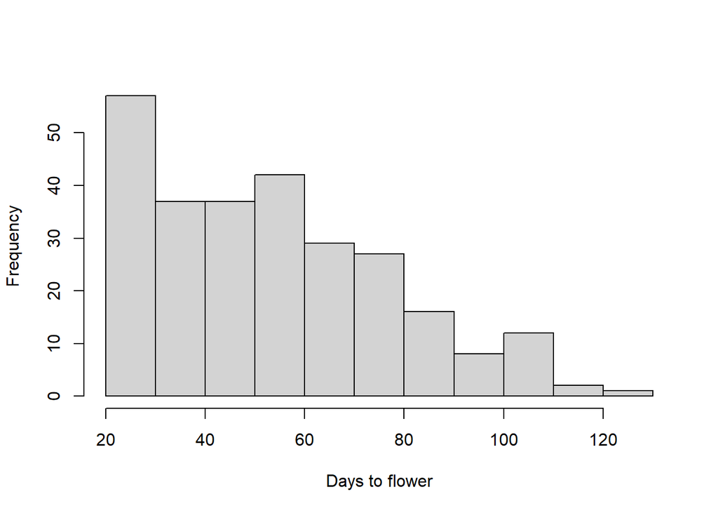

```r
hist(vern1$Days.to.Flower,main="",xlab="Days to flower")
```

We make a stripplot of flowering time as a function of both genotype and vernalization.

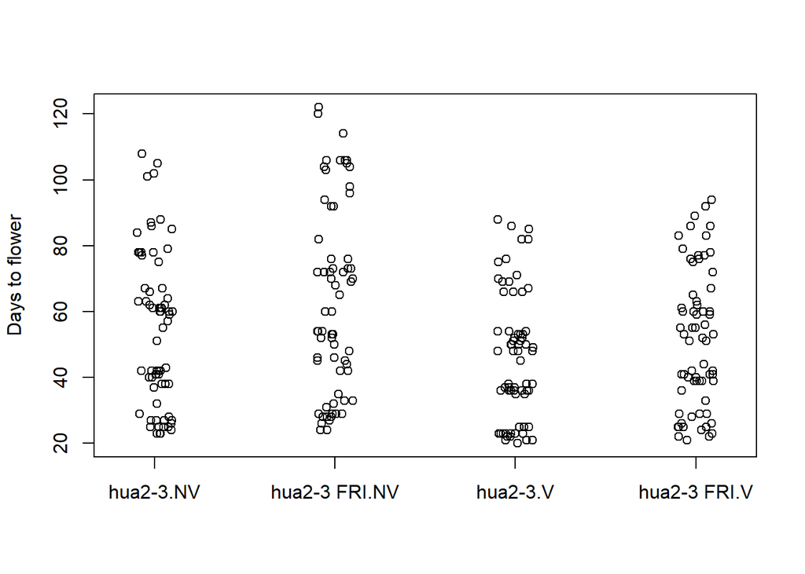

```r
stripchart(vern1$Days.to.Flower~vern1$Genotype+vern1$Vernalization,
           method="jitter",vertical=TRUE,pch=21,ylab="Days to flower")
```

Vernalization seems to speed up flowering in both strains. The FRI strain has later flowering in both vernalization conditions. This is consistent with expectation.

In experiments like this there are three common questions:

- Do the two factors affect the response? (Overall effect)
- Does each factor affect the response individually? (Main effects)
- Does the effect of one factor depend on the other? (Interaction effect)

In the context of this experiment the questions translate to:

- Does flowering time vary by vernalization and genotype?
- Do vernalization and genotype affect flowering time separately?
- Does the effect of genotype depend on vernalization (or vice versa)?

We can look at it more closely by getting the means for all four genotype/vernalization combinations, and the sample sizes (non-missing data) for each of the four categories.

```r
## means
vernMeans <- tapply(vern1$Days.to.Flower,
                    select(vern1,Genotype,Vernalization),mean,na.rm=T)
## sample sizes
vernN <- tapply(!is.na(vern1$Days.to.Flower),
                    select(vern1,Genotype,Vernalization),sum)
## display
cbind(vernMeans,vernN)
```

```
##                  NV        V NV  V
## hua2-3     54.02941 45.92537 68 67
## hua2-3 FRI 63.32308 51.88235 65 68
```

## The intercept

The four combinations appear to have different means. Let’s get the overall mean.

```r
mean(vern1$Days.to.Flower,na.rm=T)
```

```
## [1] 53.71269
```

Now we fit a linear model with just the intercept. It gives us the overall mean.

```r
summary(lm(Days.to.Flower~1,data=vern1))
```

```
##
## Call:
## lm(formula = Days.to.Flower ~ 1, data = vern1)
##
## Residuals:
##     Min      1Q  Median      3Q     Max
## -33.713 -17.713  -2.713  16.287  68.287
##
## Coefficients:
##             Estimate Std. Error t value Pr(>|t|)
## (Intercept)   53.713      1.457   36.86   <2e-16 ***
## ---
## Signif. codes:  0 '***' 0.001 '**' 0.01 '*' 0.05 '.' 0.1 ' ' 1
##
## Residual standard error: 23.85 on 267 degrees of freedom
##   (2 observations deleted due to missingness)
```

## Main effects

Next we fit a linear model with just genotype as predictor. We compare the output of this model to getting the means in each genotype category ignoring vernalization.

```r
summary(lm(Days.to.Flower~Genotype,data=vern1))
```

```
##
## Call:
## lm(formula = Days.to.Flower ~ Genotype, data = vern1)
##
## Residuals:
##     Min      1Q  Median      3Q     Max
## -36.474 -18.474  -2.974  15.993  64.526
##
## Coefficients:
##                    Estimate Std. Error t value Pr(>|t|)
## (Intercept)          50.007      2.031  24.617   <2e-16 ***
## Genotypehua2-3 FRI    7.466      2.884   2.589   0.0102 *
## ---
## Signif. codes:  0 '***' 0.001 '**' 0.01 '*' 0.05 '.' 0.1 ' ' 1
##
## Residual standard error: 23.6 on 266 degrees of freedom
##   (2 observations deleted due to missingness)
## Multiple R-squared:  0.02458,    Adjusted R-squared:  0.02092
## F-statistic: 6.704 on 1 and 266 DF,  p-value: 0.01015
```

```r
tapply(vern1$Days.to.Flower,vern1$Genotype,mean,na.rm=T)
```

```
##     hua2-3 hua2-3 FRI
##   50.00741   57.47368
```

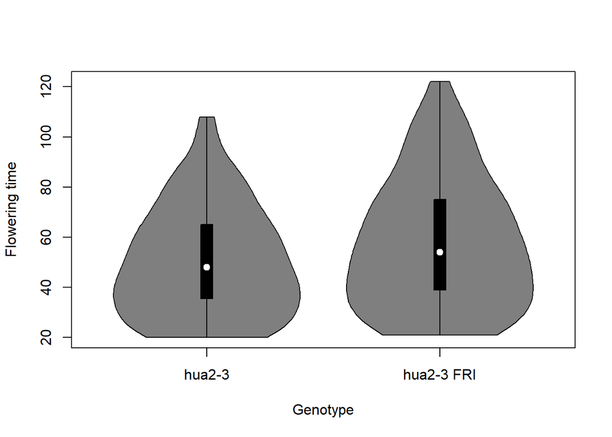

```r
vioplot::vioplot(vern1$Days.to.Flower~vern1$Genotype,xlab="Genotype",ylab="Flowering time")
```

As we know from before, the intercept is the mean of the first level of the genotype factor (`hua2-3`), and the genotype effect is the difference in the means of the two genotypes. The FRI genotype flowers about 7.5 days later. This is the main effect of genotype which is defined as the difference in the means between two genotype groups.

Now let us do the same with vernalization.

```r
summary(lm(Days.to.Flower~Vernalization,data=vern1))
```

```
##
## Call:
## lm(formula = Days.to.Flower ~ Vernalization, data = vern1)
##
## Residuals:
##     Min      1Q  Median      3Q     Max
## -35.571 -18.910  -0.926  16.163  63.429
##
## Coefficients:
##                Estimate Std. Error t value Pr(>|t|)
## (Intercept)      58.571      2.029  28.862  < 2e-16 ***
## VernalizationV   -9.646      2.859  -3.373 0.000853 ***
## ---
## Signif. codes:  0 '***' 0.001 '**' 0.01 '*' 0.05 '.' 0.1 ' ' 1
##
## Residual standard error: 23.4 on 266 degrees of freedom
##   (2 observations deleted due to missingness)
## Multiple R-squared:  0.04103,    Adjusted R-squared:  0.03742
## F-statistic: 11.38 on 1 and 266 DF,  p-value: 0.000853
```

```r
tapply(vern1$Days.to.Flower,vern1$Vernalization,mean,na.rm=T)
```

```
##       NV        V
## 58.57143 48.92593
```

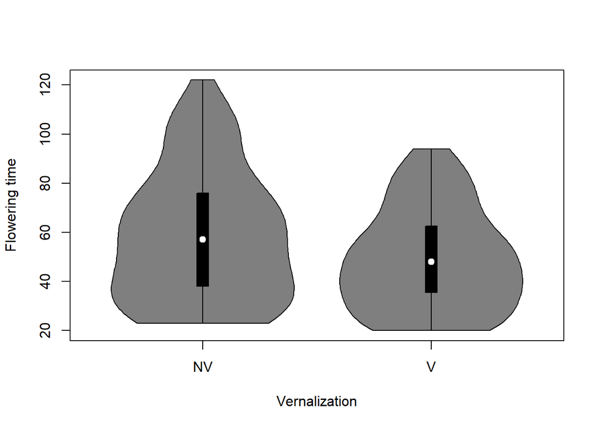

```r
vioplot::vioplot(vern1$Days.to.Flower~vern1$Vernalization,xlab="Vernalization",ylab="Flowering time")
```

Again, the results are exactly as expected. Vernalization leads to flowering about 9.6 days earlier.

Now, let’s add the two terms together.

```r
summary(lm(Days.to.Flower~Genotype+Vernalization,data=vern1))
```

```
##
## Call:
## lm(formula = Days.to.Flower ~ Genotype + Vernalization, data = vern1)
##
## Residuals:
##     Min      1Q  Median      3Q     Max
## -38.464 -18.004  -0.398  12.606  59.536
##
## Coefficients:
##                    Estimate Std. Error t value Pr(>|t|)
## (Intercept)          54.851      2.436  22.521  < 2e-16 ***
## Genotypehua2-3 FRI    7.612      2.827   2.693 0.007529 **
## VernalizationV       -9.760      2.827  -3.453 0.000646 ***
## ---
## Signif. codes:  0 '***' 0.001 '**' 0.01 '*' 0.05 '.' 0.1 ' ' 1
##
## Residual standard error: 23.13 on 265 degrees of freedom
##   (2 observations deleted due to missingness)
## Multiple R-squared:  0.06657,    Adjusted R-squared:  0.05953
## F-statistic:  9.45 on 2 and 265 DF,  p-value: 0.0001085
```

```r
ftMeans <- tapply(vern1$Days.to.Flower,
                     select(vern1,Genotype,Vernalization),mean,na.rm=T)
ftMeans
```

```
##             Vernalization
## Genotype           NV        V
##   hua2-3     54.02941 45.92537
##   hua2-3 FRI 63.32308 51.88235
```

The coefficient corresponding to vernalization is the vernalization effect averaged over genotype. This is the *main effect* of vernalization *adjusting* for genotype.

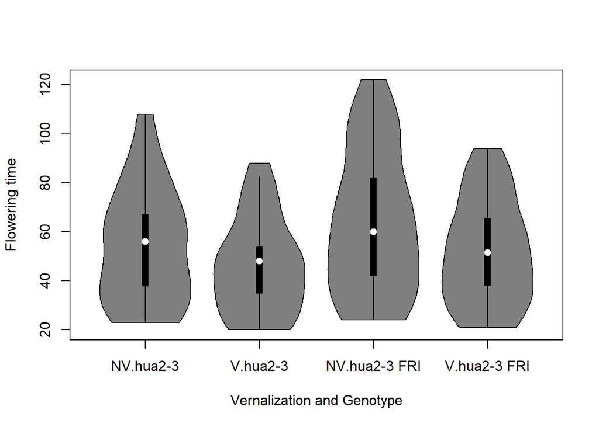

```r
vioplot::vioplot(vern1$Days.to.Flower~vern1$Vernalization*vern1$Genotype,xlab="Vernalization and Genotype",ylab="Flowering time")
```

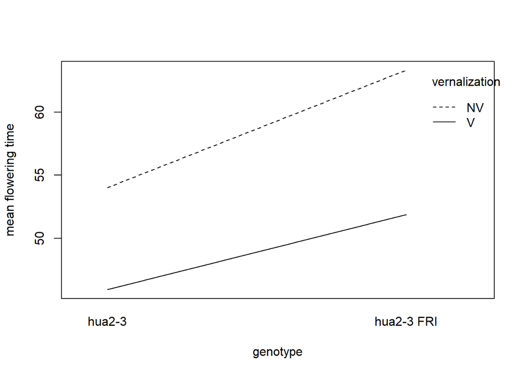

```r
interaction.plot(vern1$Genotype,vern1$Vernalization,vern1$Days.to.Flower,fun=function(x){mean(x,na.rm=TRUE)},
                 ylab="mean flowering time",xlab="genotype",trace.label="vernalization")
```

```r
vernEffect <- ftMeans[,2]-ftMeans[,1]
vernEffect
```

```
##     hua2-3 hua2-3 FRI
##  -8.104039 -11.440724
```

```r
mean(vernEffect)
```

```
## [1] -9.772381
```

Note that this is different from the vernalization effect *ignoring* genotype.

In a similar way, we can get the genotype effect averaging over vernalization, the main effect of genotype.

```r
genoEffect <- ftMeans[2,] - ftMeans[1,]
mean(genoEffect)
```

```
## [1] 7.625322
```

## Interaction effects

If the effect of one factor depends on another, we say that there is an interaction effect between the two factors. We calculated the vernalization effect in both genotypes before.

```r
vernEffect
```

```
##     hua2-3 hua2-3 FRI
##  -8.104039 -11.440724
```

They are slightly different. The difference between the two is the interaction effect.

```r
vernEffect[2] - vernEffect[1]
```

```
## hua2-3 FRI
##  -3.336685
```

To fit an interaction term we use the `:` operator. We can also use the `*` operator which is then understood to include both main effects and the interaction. In general, we should always include main effects when we fit interactions.

```r
options(contrasts=c("contr.treatment","contr.poly"))
summary(lm(Days.to.Flower~Genotype*Vernalization,data=vern1))
```

```
##
## Call:
## lm(formula = Days.to.Flower ~ Genotype * Vernalization, data = vern1)
##
## Residuals:
##     Min      1Q  Median      3Q     Max
## -39.323 -18.463  -0.382  12.971  58.677
##
## Coefficients:
##                                   Estimate Std. Error t value Pr(>|t|)
## (Intercept)                         54.029      2.809  19.236   <2e-16 ***
## Genotypehua2-3 FRI                   9.294      4.018   2.313   0.0215 *
## VernalizationV                      -8.104      3.987  -2.033   0.0431 *
## Genotypehua2-3 FRI:VernalizationV   -3.337      5.660  -0.589   0.5560
## ---
## Signif. codes:  0 '***' 0.001 '**' 0.01 '*' 0.05 '.' 0.1 ' ' 1
##
## Residual standard error: 23.16 on 264 degrees of freedom
##   (2 observations deleted due to missingness)
## Multiple R-squared:  0.0678, Adjusted R-squared:  0.05721
## F-statistic: 6.401 on 3 and 264 DF,  p-value: 0.0003354
```

You will get the same output if you specify main effects and interactions as below.

```r
summary(lm(Days.to.Flower~Genotype+Vernalization+Genotype:Vernalization,data=vern1))
```

```
##
## Call:
## lm(formula = Days.to.Flower ~ Genotype + Vernalization + Genotype:Vernalization,
##     data = vern1)
##
## Residuals:
##     Min      1Q  Median      3Q     Max
## -39.323 -18.463  -0.382  12.971  58.677
##
## Coefficients:
##                                   Estimate Std. Error t value Pr(>|t|)
## (Intercept)                         54.029      2.809  19.236   <2e-16 ***
## Genotypehua2-3 FRI                   9.294      4.018   2.313   0.0215 *
## VernalizationV                      -8.104      3.987  -2.033   0.0431 *
## Genotypehua2-3 FRI:VernalizationV   -3.337      5.660  -0.589   0.5560
## ---
## Signif. codes:  0 '***' 0.001 '**' 0.01 '*' 0.05 '.' 0.1 ' ' 1
##
## Residual standard error: 23.16 on 264 degrees of freedom
##   (2 observations deleted due to missingness)
## Multiple R-squared:  0.0678, Adjusted R-squared:  0.05721
## F-statistic: 6.401 on 3 and 264 DF,  p-value: 0.0003354
```

You will fit the same underlying model, but parametrized differently, if you use the `:` operator on its own.

```r
summary(lm(Days.to.Flower~Genotype:Vernalization,data=vern1))
```

```
##
## Call:
## lm(formula = Days.to.Flower ~ Genotype:Vernalization, data = vern1)
##
## Residuals:
##     Min      1Q  Median      3Q     Max
## -39.323 -18.463  -0.382  12.971  58.677
##
## Coefficients: (1 not defined because of singularities)
##                                    Estimate Std. Error t value Pr(>|t|)
## (Intercept)                          51.882      2.809  18.471  < 2e-16 ***
## Genotypehua2-3:VernalizationNV        2.147      3.972   0.541  0.58929
## Genotypehua2-3 FRI:VernalizationNV   11.441      4.018   2.848  0.00475 **
## Genotypehua2-3:VernalizationV        -5.957      3.987  -1.494  0.13634
## Genotypehua2-3 FRI:VernalizationV        NA         NA      NA       NA
## ---
## Signif. codes:  0 '***' 0.001 '**' 0.01 '*' 0.05 '.' 0.1 ' ' 1
##
## Residual standard error: 23.16 on 264 degrees of freedom
##   (2 observations deleted due to missingness)
## Multiple R-squared:  0.0678, Adjusted R-squared:  0.05721
## F-statistic: 6.401 on 3 and 264 DF,  p-value: 0.0003354
```

This model is overparametrized, so we will drop the intercept, and that model makes sense as it will return the flowering time means for the four categories.

```r
summary(lm(Days.to.Flower~Genotype:Vernalization+0,data=vern1))
```

```
##
## Call:
## lm(formula = Days.to.Flower ~ Genotype:Vernalization + 0, data = vern1)
##
## Residuals:
##     Min      1Q  Median      3Q     Max
## -39.323 -18.463  -0.382  12.971  58.677
##
## Coefficients:
##                                    Estimate Std. Error t value Pr(>|t|)
## Genotypehua2-3:VernalizationNV       54.029      2.809   19.24   <2e-16 ***
## Genotypehua2-3 FRI:VernalizationNV   63.323      2.873   22.04   <2e-16 ***
## Genotypehua2-3:VernalizationV        45.925      2.830   16.23   <2e-16 ***
## Genotypehua2-3 FRI:VernalizationV    51.882      2.809   18.47   <2e-16 ***
## ---
## Signif. codes:  0 '***' 0.001 '**' 0.01 '*' 0.05 '.' 0.1 ' ' 1
##
## Residual standard error: 23.16 on 264 degrees of freedom
##   (2 observations deleted due to missingness)
## Multiple R-squared:  0.8469, Adjusted R-squared:  0.8446
## F-statistic: 365.1 on 4 and 264 DF,  p-value: < 2.2e-16
```

## Specifying contrasts

By default, models with factor variables are fitted using “treatment” contrasts, which means that if there are more than two factor levels, the parameter estimates are contrasts (differences) between a factor level and a reference level (which is chosen to be the first one). Most of the time you will not want to change the default. Sometimes, there is no natural reference, and in that case a common choice is to use the average of the factor levels as the reference. We can do this by changing the way contrasts are specified.

First, let us look at the output from the default.

```r
summary(lm(Days.to.Flower~Vernalization,data=vern1))
```

```
##
## Call:
## lm(formula = Days.to.Flower ~ Vernalization, data = vern1)
##
## Residuals:
##     Min      1Q  Median      3Q     Max
## -35.571 -18.910  -0.926  16.163  63.429
##
## Coefficients:
##                Estimate Std. Error t value Pr(>|t|)
## (Intercept)      58.571      2.029  28.862  < 2e-16 ***
## VernalizationV   -9.646      2.859  -3.373 0.000853 ***
## ---
## Signif. codes:  0 '***' 0.001 '**' 0.01 '*' 0.05 '.' 0.1 ' ' 1
##
## Residual standard error: 23.4 on 266 degrees of freedom
##   (2 observations deleted due to missingness)
## Multiple R-squared:  0.04103,    Adjusted R-squared:  0.03742
## F-statistic: 11.38 on 1 and 266 DF,  p-value: 0.000853
```

We can examine the default from the output of the `options` command as follows. It lists the contrasts that will be used for unordered and ordered factors. For unordered factors it will use “treatment” contrasts and for ordered factors it willuse “polynomial” contrasts.

```r
options()$contrasts
```

```
## [1] "contr.treatment" "contr.poly"
```

```r
options(contrasts=c("contr.sum","contr.poly"))
summary(lm(Days.to.Flower~Vernalization,data=vern1))
```

```
##
## Call:
## lm(formula = Days.to.Flower ~ Vernalization, data = vern1)
##
## Residuals:
##     Min      1Q  Median      3Q     Max
## -35.571 -18.910  -0.926  16.163  63.429
##
## Coefficients:
##                Estimate Std. Error t value Pr(>|t|)
## (Intercept)      53.749      1.430  37.596  < 2e-16 ***
## Vernalization1    4.823      1.430   3.373 0.000853 ***
## ---
## Signif. codes:  0 '***' 0.001 '**' 0.01 '*' 0.05 '.' 0.1 ' ' 1
##
## Residual standard error: 23.4 on 266 degrees of freedom
##   (2 observations deleted due to missingness)
## Multiple R-squared:  0.04103,    Adjusted R-squared:  0.03742
## F-statistic: 11.38 on 1 and 266 DF,  p-value: 0.000853
```

The default in SAS is to use the `last` level as the reference. If we use this option, the estimates also change.

```r
options(contrasts=c("contr.SAS","contr.poly"))
summary(lm(Days.to.Flower~Vernalization,data=vern1))
```

```
##
## Call:
## lm(formula = Days.to.Flower ~ Vernalization, data = vern1)
##
## Residuals:
##     Min      1Q  Median      3Q     Max
## -35.571 -18.910  -0.926  16.163  63.429
##
## Coefficients:
##                 Estimate Std. Error t value Pr(>|t|)
## (Intercept)       48.926      2.014  24.290  < 2e-16 ***
## VernalizationNV    9.646      2.859   3.373 0.000853 ***
## ---
## Signif. codes:  0 '***' 0.001 '**' 0.01 '*' 0.05 '.' 0.1 ' ' 1
##
## Residual standard error: 23.4 on 266 degrees of freedom
##   (2 observations deleted due to missingness)
## Multiple R-squared:  0.04103,    Adjusted R-squared:  0.03742
## F-statistic: 11.38 on 1 and 266 DF,  p-value: 0.000853
```

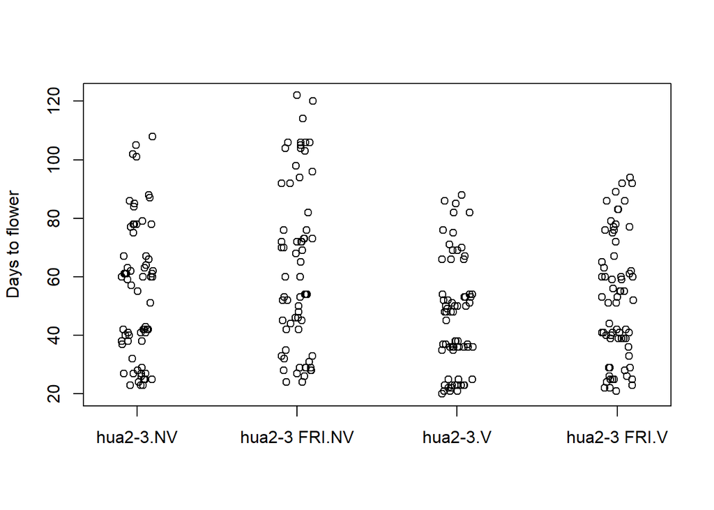

```r
stripchart(vern1$Days.to.Flower~vern1$Genotype+vern1$Vernalization,
           method="jitter",vertical=TRUE,pch=21,ylab="Days to flower")
```

```r
options(contrasts=c("contr.treatment","contr.poly"))
summary(lm(Days.to.Flower~Genotype*Vernalization,data=vern1))
```

```
##
## Call:
## lm(formula = Days.to.Flower ~ Genotype * Vernalization, data = vern1)
##
## Residuals:
##     Min      1Q  Median      3Q     Max
## -39.323 -18.463  -0.382  12.971  58.677
##
## Coefficients:
##                                   Estimate Std. Error t value Pr(>|t|)
## (Intercept)                         54.029      2.809  19.236   <2e-16 ***
## Genotypehua2-3 FRI                   9.294      4.018   2.313   0.0215 *
## VernalizationV                      -8.104      3.987  -2.033   0.0431 *
## Genotypehua2-3 FRI:VernalizationV   -3.337      5.660  -0.589   0.5560
## ---
## Signif. codes:  0 '***' 0.001 '**' 0.01 '*' 0.05 '.' 0.1 ' ' 1
##
## Residual standard error: 23.16 on 264 degrees of freedom
##   (2 observations deleted due to missingness)
## Multiple R-squared:  0.0678, Adjusted R-squared:  0.05721
## F-statistic: 6.401 on 3 and 264 DF,  p-value: 0.0003354
```

## Summary

- The effects of more than one categorical variables can be expressed as main effects and interactions. The type of model we wish to fit can be expressed using a model formula.
- While this note discussed linear models, the same concepts are applicable to non-linear models such as logistic regression or Cox proportional hazards models.
- The computer output we get from the model fitting functions depend on how we code the constrasts between factor levels. The meaning and interpretation of the output depends on the coding; sometimes it is necessary to change the defaults.